# Project 1: Investigating GAPMINDER WORLD

### NB: The following questions will be based on the data from 1950 and onwards

#### QUESTION 2

###### What are the notable differences and similarities between India and Brunei, with regards to life expectancy, children per woman, child mortality from 1950 going onwards

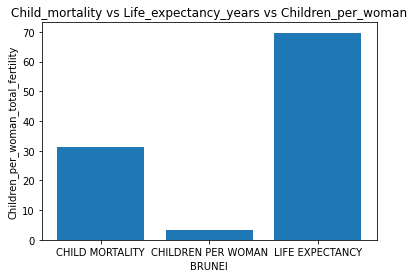

```python
plt.bar(['CHILD MORTALITY', 'CHILDREN PER WOMAN', 'LIFE EXPECTANCY'], [Brunei_subset.child_mortality.mean(), Brunei_subset.children_per_woman.mean(), Brunei_subset.life_expectancy.mean() ])
plt.ylabel('Children_per_woman_total_fertility')
plt.xlabel('BRUNEI')
plt.title('Child_mortality vs Life_expectancy_years vs Children_per_woman');
```

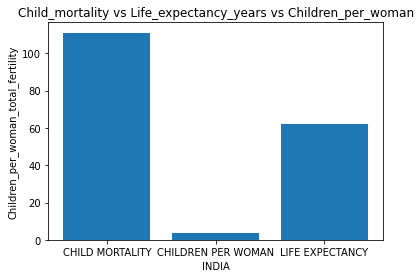

```python
plt.bar(['CHILD MORTALITY', 'CHILDREN PER WOMAN', 'LIFE EXPECTANCY'], [India_subset.child_mortality.mean(), India_subset.children_per_woman.mean(), India_subset.life_expectancy.mean() ])
plt.ylabel('Children_per_woman_total_fertility')
plt.xlabel('INDIA')
plt.title('Child_mortality vs Life_expectancy_years vs Children_per_woman');
```

India recorded the highest on: child mortality and child per woman. Brunei has significantly the highest record of life_expectancy_years

##### QUESTION 3A

###### Which factors significatly contribute to the increase in population for Brunei?

```python
p_corr = Brunei_subset['population'].corr(Brunei_subset['income'])
p_corr
```

```
0.08721719784927198
```

```python
p_corr = Brunei_subset['population'].corr(Brunei_subset['child_mortality'])
p_corr
```

```
-0.8243690827295428
```

```python
p_corr = Brunei_subset['population'].corr(Brunei_subset['children_per_woman'])
p_corr
```

```
-0.9660942214981186
```

```python
p_corr = Brunei_subset['population'].corr(Brunei_subset['life_expectancy'])
p_corr
```

```
0.9490986390474456
```

There is a positive correlation between population, life expectancy and income, where its strongest between population and life expectancy.

##### QUESTION 3B

###### Which factors significatly contribute to the increase in population for India?

```python
p_corr = India_subset['population'].corr(India_subset['life_expectancy'])
p_corr
```

```
0.994529283282013
```

```python
p_corr = India_subset['population'].corr(India_subset['income'])
p_corr
```

```
0.8736455634135127
```

```python
p_corr = India_subset['population'].corr(India_subset['children_per_woman'])
p_corr
```

```
-0.9897851016864547
```

```python
p_corr = India_subset['population'].corr(India_subset['child_mortality'])
p_corr
```

```
-0.9837574459070023
```

Income and life expectancy contribute highly to the increase in population in India

##### QUESTION 4

###### Which country has the highest average life expectancy and by how much does its life expectancy contribute to the total population?

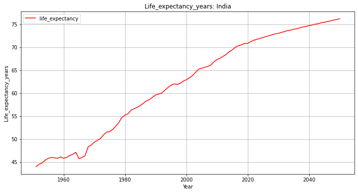

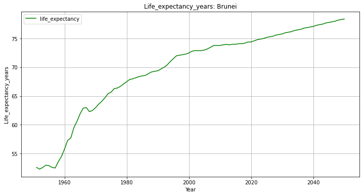

```python
line(India_subset,'year', 'Year', 'life_expectancy', 'Life_expectancy_years', 'Life_expectancy_years: India', 'r' )
line(Brunei_subset,'year', 'Year', 'life_expectancy', 'Life_expectancy_years', 'Life_expectancy_years: Brunei', 'g' );
```

Comparison between the two countries shows that Brunei has always had the highest life_expectancy_years which keeps going up year after year.

```python
p_corr = Brunei_subset['population'].corr(Brunei_subset['life_expectancy'])
p_corr
```

```
0.9490986390474456
```

##### QUESTION 5

###### Are there any notable trends common to both countries?

###### Criteria 1. Population

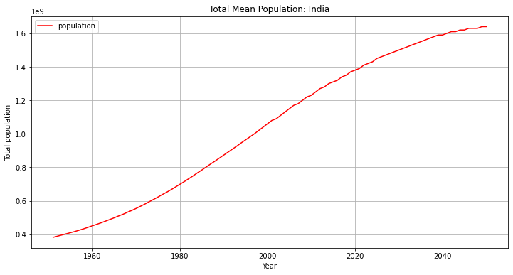

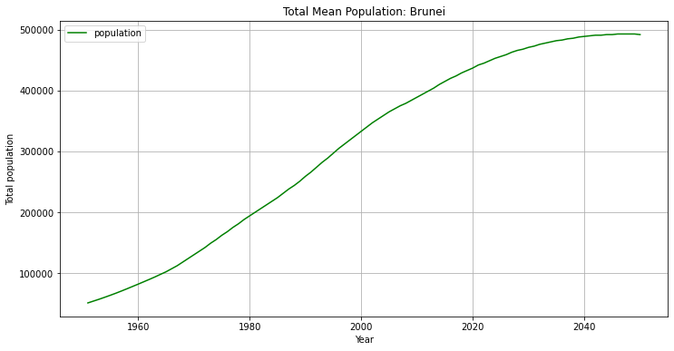

```python
line(India_subset,'year', 'Year', 'population', 'Total population', 'Total Mean Population: India', 'r' )
line(Brunei_subset,'year', 'Year', 'population', 'Total population', 'Total Mean Population: Brunei', 'g' );
```

Both countries have experienced a significant increase population as evidenced from the graphs year after year

###### Criteria 2 - Income_per_person_gdp

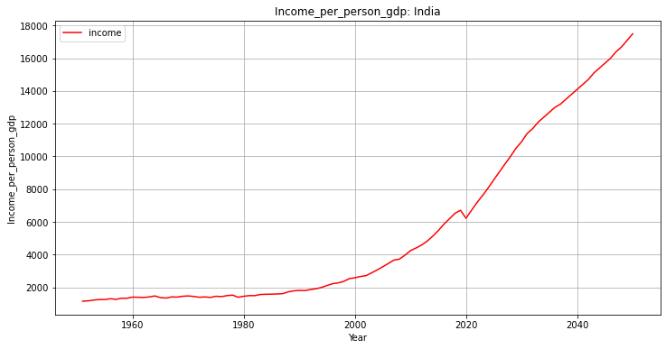

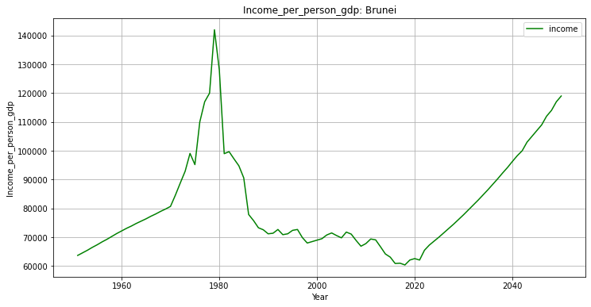

```python
line(India_subset,'year', 'Year', 'income', 'Income_per_person_gdp', 'Income_per_person_gdp: India', 'r' )
line(Brunei_subset,'year', 'Year', 'income', 'Income_per_person_gdp', 'Income_per_person_gdp: Brunei', 'g' );
```

From the above two plots,we learn that after 2020, both countries experienced a sharp increase in income_per_person_gdppercapita_ppp_inflation, they only varied in amounts.

###### Criteria 3 - Child_mortality_0_5_year_olds_dying_per_1000_born

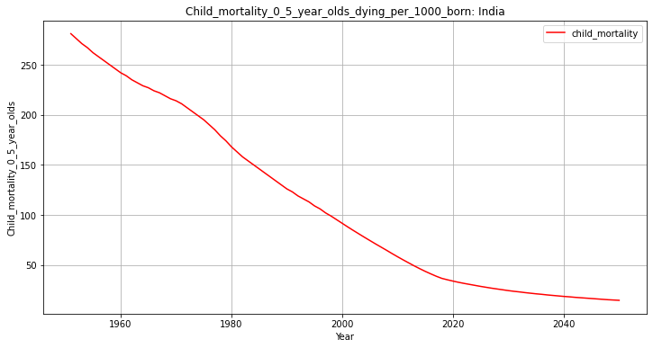

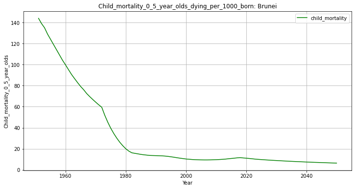

```python
line(India_subset,'year', 'Year', 'child_mortality', 'Child_mortality_0_5_year_olds', 'Child_mortality_0_5_year_olds_dying_per_1000_born: India', 'r' )
line(Brunei_subset,'year', 'Year', 'child_mortality', 'Child_mortality_0_5_year_olds', 'Child_mortality_0_5_year_olds_dying_per_1000_born: Brunei', 'g' );
```

###### Criteria 4 - children_per_woman_total_fertility

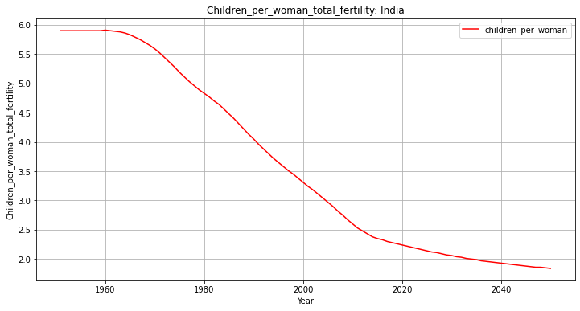

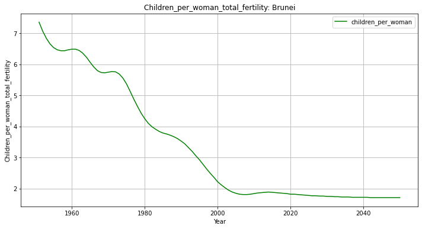

```python
line(India_subset,'year', 'Year', 'children_per_woman', 'Children_per_woman_total_fertility', 'Children_per_woman_total_fertility: India', 'r' )
line(Brunei_subset,'year', 'Year', 'children_per_woman', 'Children_per_woman_total_fertility', 'Children_per_woman_total_fertility: Brunei', 'g' );
```

Contrary to a history or trend of having the highest record in children_per_woman_total_fertility, towards the 1980s Brunei started experiencing a yearly decline, recording the lowest as compared to India.

##### QUESTION 6

###### Is there relationship between children_per_woman_total_fertility and child_mortality_0_5_year_olds_dying_per_1000_born and how do they both affect or contribute to the total population life expectancy years in Brunei?

```
0.8283736369126777
```

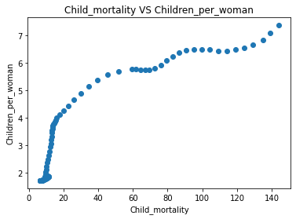

```python
plt.scatter(Brunei_subset['child_mortality'], Brunei_subset['children_per_woman']);
p_corr = df_brunei['child_mortality'].corr(df_brunei['children_per_woman'])
plt.xlabel('Child_mortality')
plt.ylabel('Children_per_woman')
plt.title('Child_mortality VS Children_per_woman')
print(p_corr)
```

```python
p_corr = Brunei_subset['population'].corr(Brunei_subset['child_mortality'])
p_corr
```

```
-0.8243690827295428
```

```python
p_corr = Brunei_subset['population'].corr(Brunei_subset['children_per_woman'])
p_corr
```

```
-0.9660942214981186
```

```python
p_corr = Brunei_subset['life_expectancy'].corr(Brunei_subset['children_per_woman'])
p_corr
```

```
-0.9627062361637827
```

```python
p_corr = Brunei_subset['life_expectancy'].corr(Brunei_subset['child_mortality'])
p_corr
```

```
-0.9468250838449066
```

## LIMITATIONS

1. The data doesn't give an insight or provide documentation on externall factors (e.g. political and socio-economic issues)that contributed to the various changes observed. This would assist in understanding the different trends observed over the years. For example 'what caused the rapid decline of income_per_person_gdppercapita_ppp_inflation_adjusted of Brunei in the late 1970s as shown in the graph above?'
2. The countries were not grouped by region/continent which would have made it easy to analyse the whole dataset then performing an analysis on particular region(s) incase there were common trends. Manually grouping them would have been time consuming.

## REFERENCES

https://realpython.com/

https://www.statology.org/python-guides/

https://stackoverflow.com/

https://pandas.pydata.org/pandas-docs/stable/user_guide/index.html